# Lab 5 Assignment | PAF 516

Temporal Change Analysis — 2013 → 2019

```r
# ── One-time course environment setup ─────────────────────────────────────
if (!file.exists("~/.paf516_ready")) {
  if (!requireNamespace("renv", quietly = TRUE)) install.packages("renv")
  tmp <- tempfile(fileext = ".lock")
  download.file(
    url      = "https://raw.githubusercontent.com/AntJam-Howell/paf-516-labs/main/renv.lock",
    destfile = tmp, mode = "wb"
  )
  renv::restore(lockfile = tmp, prompt = FALSE)
  file.create("~/.paf516_ready")
}

library(tidyverse)
library(tidycensus)
library(sf)
library(viridis)
library(patchwork)
library(spdep)
```

# Overview

**Rename this file** `Lab5_Assignment_YourLastName.qmd` before editing. Submit both the `.qmd` and rendered `.html` to Canvas.

**Instructions:**

1. Steps 1–9 (pre-filled) run automatically when you render — review all output before answering.
2. Q1 requires written interpretation only.
3. Q2 requires complete R code and output.
4. Q3 requires written interpretation of your Q2 results.

**Index: 3 variables** — poverty rate (C17002), unemployment rate (B23025), median household income (B19013, reversed). Both years use 2009–2013 and 2015–2019 ACS 5-year estimates, both on 2010 TIGER/Line tract boundaries.

# Step 1: Variables

```r
hardship_vars <- c(
  pov_below50   = "C17002_002",
  pov_50to99    = "C17002_003",
  pov_den       = "C17002_001",
  unemp_num     = "B23025_005",
  unemp_den     = "B23025_002",
  median_income = "B19013_001"
)
```

# Step 2: Pull Data (2013 and 2019)

```r
# ── Data: Maricopa County tracts, 2009–2013 ACS (2013) ───
tract_2013_raw <- readRDS(url("https://raw.githubusercontent.com/AntJam-Howell/paf-516-labs/main/altlabs/Lab5/data/tract_2013_raw_RAW.rds"))
```

```r
# ── Data: Maricopa County tracts, 2015–2019 ACS (2019) ───
tract_2019_raw <- readRDS(url("https://raw.githubusercontent.com/AntJam-Howell/paf-516-labs/main/altlabs/Lab5/data/tract_2019_raw_RAW.rds"))
```

# Step 3: Reshape and Compute Rates

```r
widen_and_rate <- function(df) {
  df %>%
    select(-moe) %>%
    pivot_wider(names_from = variable, values_from = estimate) %>%
    mutate(
      poverty_rate = (pov_below50 + pov_50to99) / pov_den,
      unemp_rate   = unemp_num / unemp_den
    ) %>%
    filter(!is.na(poverty_rate), !is.na(unemp_rate), !is.na(median_income))
}

tract_2013_wide <- widen_and_rate(tract_2013_raw)
tract_2019_wide <- widen_and_rate(tract_2019_raw)

cat("2013 tracts:", nrow(tract_2013_wide), "| 2019 tracts:", nrow(tract_2019_wide), "\n")
```

```
2013 tracts: 906 | 2019 tracts: 905
```

# Step 4: Pooled Standardization

```r
r2013 <- tract_2013_wide %>% st_drop_geometry() %>%
  select(GEOID, poverty_rate, unemp_rate, median_income)
r2019 <- tract_2019_wide %>% st_drop_geometry() %>%
  select(GEOID, poverty_rate, unemp_rate, median_income)

vars_to_pool <- c("poverty_rate", "unemp_rate", "median_income")

# Pooled mean and SD across both years combined
pooled_stats <- map_dfr(vars_to_pool, function(v) {
  vals <- c(r2013[[v]], r2019[[v]])
  tibble(variable = v, mean = mean(vals, na.rm = TRUE), sd = sd(vals, na.rm = TRUE))
})

apply_pooled_z <- function(df, stats) {
  for (v in stats$variable) {
    pm <- stats$mean[stats$variable == v]
    ps <- stats$sd[stats$variable == v]
    df[[paste0("z_", v)]] <- (df[[v]] - pm) / ps
  }
  df$z_median_income <- -1 * df$z_median_income
  df$hardship_index <- rowMeans(
    df[, c("z_poverty_rate", "z_unemp_rate", "z_median_income")],
    na.rm = TRUE)
  return(df)
}

r2013_z <- apply_pooled_z(r2013, pooled_stats)
r2019_z <- apply_pooled_z(r2019, pooled_stats)

cat("Mean economic hardship index 2013:", round(mean(r2013_z$hardship_index), 3),
    "  Mean economic hardship index 2019:", round(mean(r2019_z$hardship_index), 3), "\n")
```

```
Mean economic hardship index 2013: 0.245   Mean economic hardship index 2019: -0.245
```

# Step 5: Join and Change Scores

```r
p2019_sf <- tract_2019_wide %>%
  select(GEOID, NAME) %>%
  left_join(r2019_z %>% select(GEOID, hardship_2019 = hardship_index), by = "GEOID")

p2013_tbl <- r2013_z %>%
  select(GEOID, hardship_2013 = hardship_index)

change_df <- inner_join(p2019_sf, p2013_tbl, by = "GEOID") %>%
  mutate(hardship_change = hardship_2019 - hardship_2013)

cat("Tracts matched:", nrow(change_df),
    "| Mean change:", round(mean(change_df$hardship_change), 3), "\n")
```

```
Tracts matched: 904 | Mean change: -0.483
```

# Step 6: MOE Significance Test

```r
# Extract poverty MOE from both raw pulls
moe_2013 <- tract_2013_raw %>%
  filter(variable %in% c("pov_below50", "pov_50to99", "pov_den")) %>%
  st_drop_geometry() %>%
  select(GEOID, variable, estimate, moe) %>%
  pivot_wider(names_from = variable, values_from = c(estimate, moe))

moe_2019 <- tract_2019_raw %>%
  filter(variable %in% c("pov_below50", "pov_50to99", "pov_den")) %>%
  st_drop_geometry() %>%
  select(GEOID, variable, estimate, moe) %>%
  pivot_wider(names_from = variable, values_from = c(estimate, moe))

# Compute poverty rate and propagated SE for each year
compute_pov_se <- function(df) {
  df %>%
    mutate(
      pov_est = (estimate_pov_below50 + estimate_pov_50to99) / estimate_pov_den,
      pov_moe = sqrt(moe_pov_below50^2 + moe_pov_50to99^2 +
                     pov_est^2 * moe_pov_den^2) / estimate_pov_den,
      pov_se  = pov_moe / 1.645
    ) %>%
    select(GEOID, pov_est, pov_se)
}

pov_2013 <- compute_pov_se(moe_2013)
pov_2019 <- compute_pov_se(moe_2019)

# Z-test: (est_2019 - est_2013) / sqrt(SE_2013^2 + SE_2019^2)
pov_sig <- inner_join(pov_2013, pov_2019,
                      by = "GEOID", suffix = c("_2013", "_2019")) %>%
  mutate(
    pov_change = pov_est_2019 - pov_est_2013,
    pov_z      = pov_change / sqrt(pov_se_2013^2 + pov_se_2019^2),
    sig_change = abs(pov_z) > 1.645
  )

change_df <- change_df %>%
  left_join(pov_sig %>% select(GEOID, sig_change), by = "GEOID")

cat("Significant poverty change:", sum(pov_sig$sig_change, na.rm = TRUE),
    sprintf("(%.1f%%)\n", 100 * mean(pov_sig$sig_change, na.rm = TRUE)))
```

```
Significant poverty change: 122 (13.4%)
```

# Step 7: Change Map

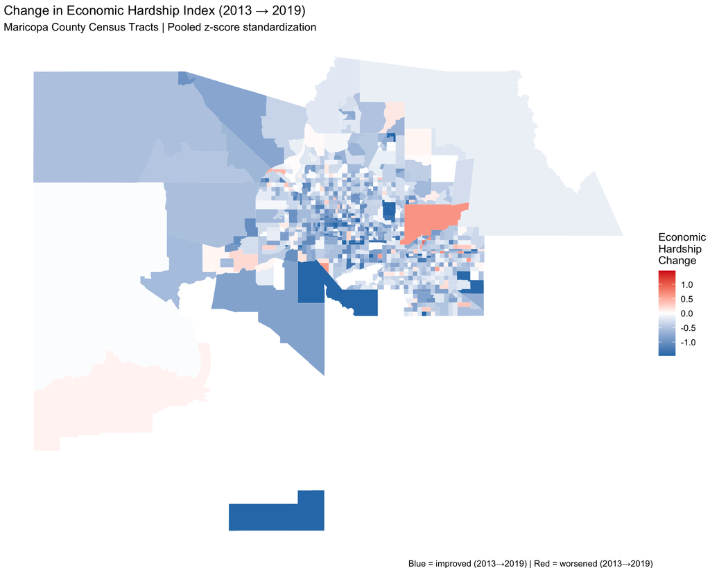

```r
lo      <- quantile(change_df$hardship_change, 0.02, na.rm = TRUE)
hi      <- quantile(change_df$hardship_change, 0.98, na.rm = TRUE)
max_abs <- max(abs(lo), abs(hi))

change_df <- change_df %>%
  mutate(change_plot = pmax(pmin(hardship_change, max_abs), -max_abs))

ggplot(change_df) +
  geom_sf(aes(fill = change_plot), color = NA) +
  scale_fill_gradient2(
    low = "#2C7BB6", mid = "white", high = "#D7191C",
    midpoint = 0, limits = c(-max_abs, max_abs), name = "Economic\nHardship\nChange"
  ) +
  theme_void() +
  labs(title    = "Change in Economic Hardship Index (2013 → 2019)",
       subtitle = "Maricopa County Census Tracts | Pooled z-score standardization",
       caption  = "Blue = improved (2013→2019) | Red = worsened (2013→2019)")
```

# Step 8: Side-by-Side Map

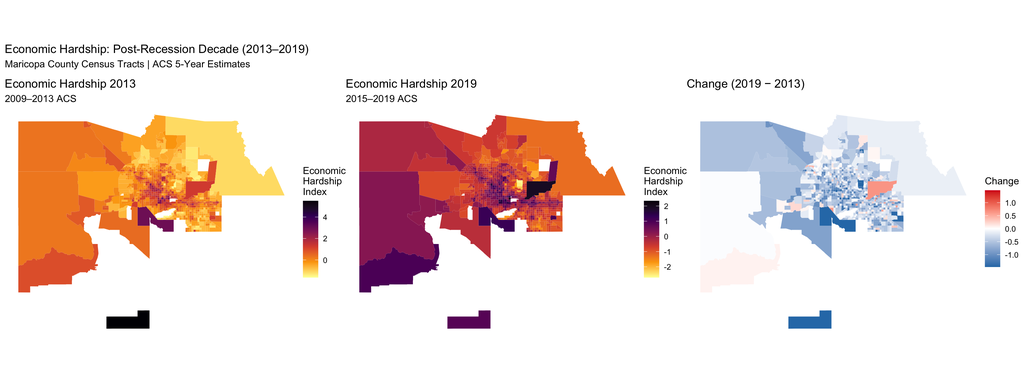

```r
p1 <- ggplot(change_df) +
  geom_sf(aes(fill = hardship_2013), color = NA) +
  scale_fill_viridis_c(option = "inferno", direction = -1, name = "Economic\nHardship\nIndex") +
  theme_void() + labs(title = "Economic Hardship 2013", subtitle = "2009–2013 ACS")

p2 <- ggplot(change_df) +
  geom_sf(aes(fill = hardship_2019), color = NA) +
  scale_fill_viridis_c(option = "inferno", direction = -1, name = "Economic\nHardship\nIndex") +
  theme_void() + labs(title = "Economic Hardship 2019", subtitle = "2015–2019 ACS")

p3 <- ggplot(change_df) +
  geom_sf(aes(fill = change_plot), color = NA) +
  scale_fill_gradient2(
    low = "#2C7BB6", mid = "white", high = "#D7191C",
    midpoint = 0, limits = c(-max_abs, max_abs), name = "Change"
  ) +
  theme_void() + labs(title = "Change (2019 − 2013)")

p1 + p2 + p3 +
  plot_annotation(title = "Economic Hardship: Post-Recession Decade (2013–2019)",
                  subtitle = "Maricopa County Census Tracts | ACS 5-Year Estimates")
```